# The Economics of Brexit

Lecture 1: Evolution of the European institutions

Dr David Chivers

Macroeconomic Applications and Policy

## Module outline

### Michaelmas Term

- **Lectures 1–5:** The Economics of Brexit (David Chivers)
- **Lectures 6–10:** Financial Globalisation: A Reappraisal (Sara Eugeni)

### Epiphany Term

- **Lectures 1–5:** Optimal Currency Areas (Xiaoshan Chen)
- **Lectures 6–10:** The International Monetary System (Sara Eugeni)

### Easter Term

- **Revision Lecture 1:** David and Xiaoshan
- **Revision Lecture 2:** Sara

## Assessment

### Summative exam

- Two-hour written, in-person exam, worth **100%** of the overall mark.
- Four sections, with two questions in each section.
- Answer **four questions**, at least one from each section.

### Formative test

- Two questions, one from each topic in Term 1.
- **1,500 words** maximum.
- Feedback on how to improve for the summative exam.
- Submission deadline: first week of Term 2.

## Exam structure

Answer **four questions**, at least one from each section. Each question carries equal weight.

| Section | Questions |
| --- | --- |
| A | 1 and 2 |
| B | 3 and 4 |
| C | 5 and 6 |
| D | 7 and 8 |

## Learning objectives

- Understand why France, Italy, West Germany and the Benelux countries started the process of European integration in the early 1950s.
- Understand the political and economic incentives for other countries to join the EU in successive waves of enlargement.
- Understand the evolution of the European institutions in their historical context.

## “A kind of United States of Europe”

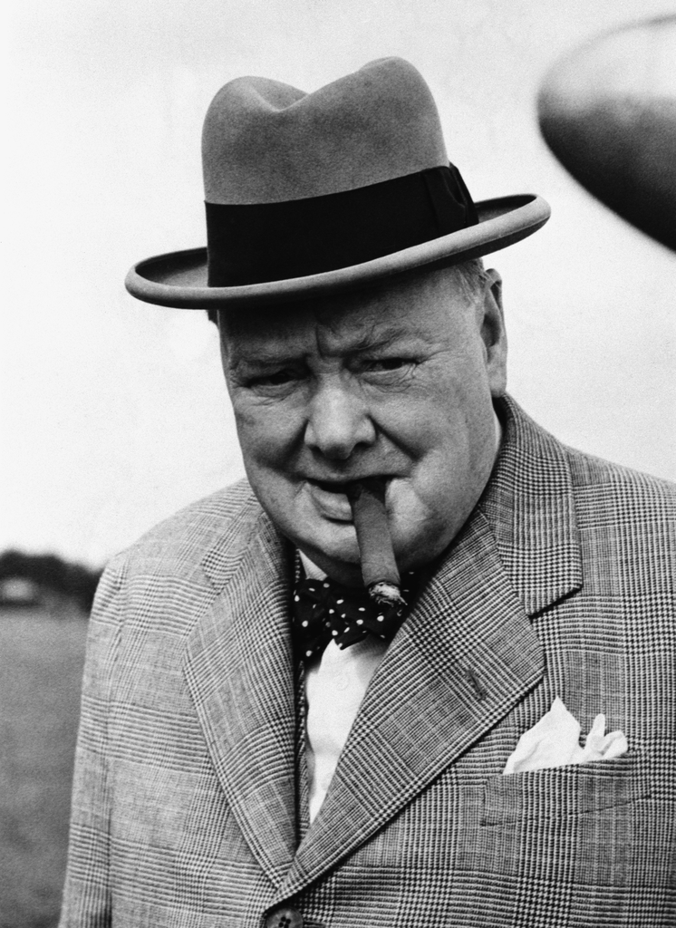

> *“Yet all the while there is a remedy… It is to re-create the European Family, or as much of it as we can, and to provide it with a structure under which it can dwell in peace, in safety and in freedom. We must build a kind of United States of Europe.”*

**Winston Churchill**  
Zurich, 19 September 1946

## A climate for radical change

Death and destruction in the Second World War

| Country | Death toll | Pre-war year when GDP equalled that of 1945 |
| --- | --- | --- |
| Austria | 525,000 | 1886 |
| Belgium | 82,750 | 1924 |
| Denmark | 4,250 | 1936 |
| Finland | 79,000 | 1938 |
| France | 505,750 | 1891 |
| Germany | 6,363,000 | 1908 |
| Italy | 355,500 | 1909 |
| Netherlands | 250,000 | 1912 |
| Norway | 10,250 | 1937 |
| Sweden | 0 | GDP grew during the war |
| Switzerland | 0 | GDP grew during the war |
| UK | 325,000 | GDP grew during the war |

Source: Crafts and Toniolo (1996), p. 4 (GDP); Encarta (deaths). Figures from the original lecture.

## The question in 1945

### How can Europe avoid another war?

**What caused the war?**

1. Blame Germany.
2. Blame capitalism.
3. Blame nationalism.

**Three different solutions**

1. “Neuter” Germany: the Morgenthau Plan of 1944.
2. Adopt communism.
3. Pursue European integration.

## The Iron Curtain

[figure not shown]

- **Western bloc**  
  NATO
- **Eastern bloc**  
  Warsaw Pact
- Neutral countries
- Non-aligned Yugoslavia
- Albania: left the Warsaw Pact in 1968
- Iron Curtain

Later Cold War alignments; memberships changed over time. Map: [Sémhur / Wikimedia Commons](https://commons.wikimedia.org/wiki/File:Iron_Curtain_map.svg), [CC BY-SA 4.0](https://creativecommons.org/licenses/by-sa/4.0/), unchanged.

## The role of the Cold War

- The Soviet vision is strongly rejected by the US and the UK, leading to the Cold War.
- A strong Germany is needed as a cushion against the communists.
- The US, UK and French zones merge.
- The Federal Republic of Germany is established in 1949.

The merger of the French, US and UK zones was a defining moment in Europe and a precursor of European integration.

## Not only idealism

- **The French:** Franco-German economic integration to avoid another war and counterbalance US–UK influence on the Continent.
- **The British and the Americans:** counter the spread of communism in Europe.
- **The Germans:** a route to re-establish Germany as a “normal” nation.
- **The Italians:** counterbalance communism and shut the door on fascism forever.
- **The Benelux nations:** avoid another Franco-German war.

## First steps

- The **OEEC** (now OECD) is created to administer US aid to Europe: the Marshall Plan.
- A first wave of trade liberalisation and the creation of the **EPU** facilitate payments.
- Can trade liberalisation help growth and industrialisation?

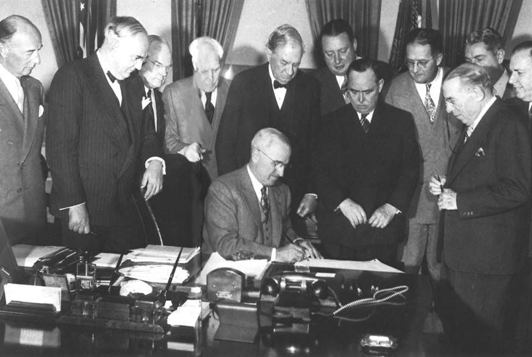

President Truman signs the Foreign Assistance Act, 3 April 1948. [George C. Marshall Foundation](https://www.marshallfoundation.org/wp-content/uploads/2014/05/Chapter_1.pdf), p. 11.

Western European trade and output growth in manufactures, 1950–58

| Country | GDP growth (% per annum) | Manufacturing export growth (% per annum) |
| --- | --- | --- |
| Germany (West) | 7.8 | 19.7 |
| Italy | 5.0 | 9.2 |
| Netherlands | 4.3 | 11.7 |
| UK | 2.0 | 1.8 |
| France | 4.4 | 3.8 |

Source as cited in the original table: Milward (1992), Table 4.1.

## A disagreement about the depth

### Intergovernmentalism

Nations retain all sovereignty.

- OEEC (1948)
- Council of Europe (1949)
- Court of Human Rights (1950)
- EFTA (1960)

### Federalism

Supranational institutions.

- **ECSC (1951):** Belgium, France, Germany, Italy, the Netherlands and Luxembourg (the “Six”) place coal and steel under a supranational authority.
- **EEC (1957):** the Six commit to a customs union, free labour mobility, capital-market integration, free trade in services and common policies.

## The Treaty of Rome: main goals

- *“The elimination, as between Member States, of customs duties and quantitative restrictions on the imports and export of goods, and of all other measures having equivalent effect”* and *“the establishment of a common customs tariff and of a common commercial policy towards third countries”*.
- *“The abolition, as between Member States, of obstacles to freedom of movement for persons, services and capital”*.
- The adoption of common policies in agriculture, transport and other areas.
- The establishment of supranational institutions: the European Commission, European Parliamentary Assembly and European Court of Justice.

[figure not shown]

Signing of the Treaty of Rome, 1957.

## Situation in the late 1960s

### Two separate trade blocs

**EEC: six members**  
A customs union

**EFTA: seven members**  
A free-trade area

Finland: EFTA associate

AT Austria · BE Belgium · CH Switzerland  
DK Denmark · LU Luxembourg  
NL Netherlands · PT Portugal

[figure not shown]

Historical membership: Baldwin and Wyplosz; [EFTA](https://www.efta.int/about-efta/european-free-trade-association/history). Map adapted from [Sémhur](https://commons.wikimedia.org/wiki/File:Iron_Curtain_map.svg), [CC BY-SA 4.0](https://creativecommons.org/licenses/by-sa/4.0/).

## The “domino effect”

- EEC incomes were growing twice as fast.
- The aggregate GDP of the EEC was much larger than EFTA: the **market-size effect**.

**The UK, Ireland and Denmark join in 1973.**

EEC: nine members  
EFTA members  
Finland: associate

Industrial free-trade agreements now link the two blocs.

[figure not shown]

Mid-1970s; industrial tariffs phased out by 1977. [EFTA history](https://www.efta.int/about-efta/european-free-trade-association/history). Map adapted from [Sémhur](https://commons.wikimedia.org/wiki/File:Iron_Curtain_map.svg), [CC BY-SA 4.0](https://creativecommons.org/licenses/by-sa/4.0/).

## Looking for freedom?

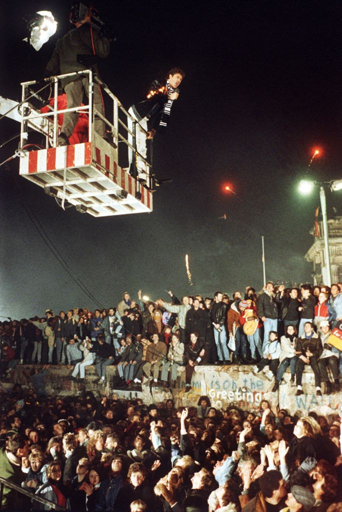

David Hasselhoff above the Berlin Wall, 31 December 1989.  
Photograph: Wöstmann/picture alliance/Getty Images, via [TIME](https://time.com/5714602/david-hasselhoff-berlin-wall-fall/).

## Single market programme: 1 January 1993

### Implementing the “four freedoms”

**Goods trade: removing non-tariff barriers**

- Streamline or eliminate border formalities.
- Harmonise VAT rates within wide bands.
- Liberalise government procurement.
- Harmonise and mutually recognise technical standards in production, packaging and marketing.

**Factor-market liberalisation**

- Remove all capital controls.
- The Erasmus programme is launched in 1987.

## European integration in the 1990s

### Enlargement

- Deeper integration in the EU12 induces a new “domino effect”.
- Finland, Sweden and Austria join in **1995**.
- The EU sets the **Copenhagen criteria** for the accession of Central and Eastern European countries.

### Deepening

- The **Maastricht Treaty**, signed in 1992, commits EU countries to monetary union by 1999 and a single currency by 2002.
- The **Schengen Agreement**, implemented in 1995, abolishes checks at borders.

[figure not shown]

[Maastricht summit, December 1991](https://audiovisual.ec.europa.eu/en/media/photo/P-002371/06-1). The treaty was signed in February 1992.

## Brexit vote, 2016

[figure not shown]

## The future place of the UK?

[figure not shown]

Historical membership diagram and UK annotation reproduced from the original lecture.

## Summing up: the economics of European integration

- European countries wanted to avoid another war and its economic destruction. Federalism and intergovernmentalism offered ways to counter extreme nationalism and its consequences.
- The European Union proved a magnet for even initially reluctant outsiders: the **market-size and domino effects**, alongside its pro-democratic role.
- **Enlargement and deepening involve a trade-off:** governance issues and disagreements across member states.

## Next lecture

The customs union

Who gains and loses  
when tariff barriers fall?

**Preparation:** Revise consumer surplus and producer surplus.

## References

### Essential reading

Baldwin and Wyplosz, *The Economics of European Integration*, **“History” (Chapter 1 in the seventh edition)**.

The [Talis reading list](https://durham.rl.talis.com/lists/d85d1ad3-e9ac-4daf-aa66-e3ddfcf902d7.html) links to the 2022 seventh edition online.

Other editions are fine; find the chapter by its title.

### Further reading

See the [ECON2271 Talis reading list](https://durham.rl.talis.com/lists/d85d1ad3-e9ac-4daf-aa66-e3ddfcf902d7.html), also available through Blackboard.

### Contact

david.chivers@durham.ac.uk